# PCA

Dados do exemplo:

```r
data = read.csv("data/notas_PCA.csv")
row.names(data) = data[,1]
data = data[,-1]
```

Os $k$ fatores que encontraremos serão uma combinação linear entre nossas $k$ variáveis $x_i$ tomadas da forma:

$F_1 = s_{11}x_{1i}+s_{21}x_{2i}+...+s_{k1}x_{ki}$ $F_2 = s_{12}x_{1i}+s_{22}x_{2i}+...+s_{k2}x_{ki}$ $...$ $F_k = s_{ik}x_{1k}+s_{2k}x_{2i}+...+s_{kk}x_{ki}$

Os coeficientes dessa combinação linear ($s_{ik}$) são chamados *scores fatoriais*.

Construção da matriz de correlações (rho):

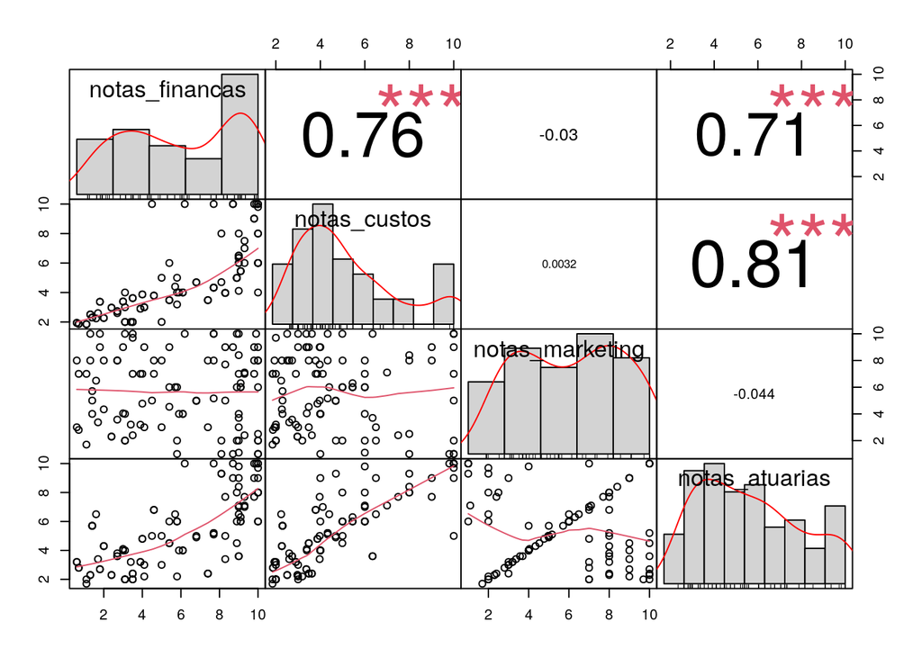

```r
rho <- cor(data)
library(PerformanceAnalytics)
chart.Correlation(data)
```

A estatística KMO:

```r
library(psych)
KMO(r = rho)
```

```
## Kaiser-Meyer-Olkin factor adequacy
## Call: KMO(r = rho)
## Overall MSA =  0.74
## MSA for each item =
##  notas_financas    notas_custos notas_marketing  notas_atuarias
##            0.81            0.69            0.21            0.73
```

Teste de esfericidade de Bartlett no qual vamos testar se nosa matriz de correlação é estatisticamente igual a matriz de identidade, ou seja, que nossas correlações são zero:

```r
cortest.bartlett(R = rho)
```

```
## $chisq
## [1] 192.3685
##
## $p.value
## [1] 7.978533e-39
##
## $df
## [1] 6
```

Temos 6 graus de liberdade. Dado o qui-quadrado 192.3685, podemos estimar o p-value (ele é dado também acima):

```r
pchisq(q = 192.3685, df = 6, lower.tail = FALSE)
```

```
## [1] 7.978454e-39
```

- Hipótese Nula: matriz de correlação é igual a matriz identidade, ou seja, zero
- Hipótese alternativa: matriz de correlação não é igual a matriz identidade, ou seja, zero

Autovalores (variâncias compartilhadas de todas as variáveis) da matriz de correlação rho (abaixo mostramos como ele é determinado):

```r
autovalores <- eigen(rho)$values
```

Explicação aproximada: Um auto valor de 2,5 significa que o fator correspondente carrega a variância compartilhada de 2 variáveis e meia da base original. A soma dos autovalores corresponde a quantidade de variáveis.

Chamando a matriz de correlações de $\rho$, os autovalores ($\lambda$) são as raízes que resolvem a equação, sendo $I$ a matriz identidade:

$det(\rho-\lambda I)=0$

Equação da operação acima, chamada de polinômio característico:

```r
library(pracma)
coeficientes <- charpoly(rho)

library(polynom)
equacao = as.polynomial(rev(coeficientes))
print(equacao)
```

```
## 0.1371619 - 1.402553*x + 4.265747*x^2 - 4*x^3 + x^4
```

Encontrando as raízes da equação (que são os autovalores):

```r
solve(equacao)
```

```
## [1] 0.1828072 0.2977321 1.0004081 2.5190527
```

Chamamos de variância compartilhada a proporção do autovalor de cada fator:

```r
variancia_compartilhada <- (autovalores/sum(autovalores))
variancia_compartilhada
```

```
## [1] 0.62976316 0.25010202 0.07443301 0.04570180
```

Variância compartilhada cumulativa:

```r
variancia_cumulativa <- cumsum(variancia_compartilhada)
variancia_cumulativa
```

```
## [1] 0.6297632 0.8798652 0.9542982 1.0000000
```

Organizando essas informações em um dataframe:

```r
principais_componentes = 1:4
report = data.frame(
           principais_componentes = paste0("PC", principais_componentes),
           eigenvalue = autovalores,
           variancia_compartilhada = variancia_compartilhada,
           variancia_cumulativa = variancia_cumulativa)
report
```

```
##   principais_componentes eigenvalue variancia_compartilhada
## 1                    PC1  2.5190527              0.62976316
## 2                    PC2  1.0004081              0.25010202
## 3                    PC3  0.2977321              0.07443301
## 4                    PC4  0.1828072              0.04570180
##   variancia_cumulativa
## 1            0.6297632
## 2            0.8798652
## 3            0.9542982
## 4            1.0000000
```

```r
library(dplyr) # para usaro operador: %>%
library(kableExtra) # sudo apt -y install libfontconfig1-dev
report %>%
  kable() %>%
  kable_styling(bootstrap_options = "striped",
                full_width = T,
                font_size = 12)
```

| principais_componentes | eigenvalue | variancia_compartilhada | variancia_cumulativa |
| --- | --- | --- | --- |
| PC1 | 2.5190527 | 0.6297632 | 0.6297632 |
| PC2 | 1.0004081 | 0.2501020 | 0.8798652 |
| PC3 | 0.2977321 | 0.0744330 | 0.9542982 |
| PC4 | 0.1828072 | 0.0457018 | 1.0000000 |